# Relación Pureza-Color de los Diamantes

Roberto Andrés Aguilar Quesada

2/26/2020

# Diamonds

Inicialmente tenemos el dataframe diamonds, el cual está contenido dentro del paquete denominado *ggplot2*. La cual puede mostrarse de forma muestral a través del siguiente formato

| Quilates | Calidad_de_corte | Color | Pureza | Porc.Prof | Tapa | Precio | Longitud | Ancho | Profundidad |
| --- | --- | --- | --- | --- | --- | --- | --- | --- | --- |
| 0.23 | Ideal | E | SI2 | 61.5 | 55.0 | 326 | 3.95 | 3.98 | 2.43 |
| 0.21 | Premium | E | SI1 | 59.8 | 61.0 | 326 | 3.89 | 3.84 | 2.31 |
| 0.23 | Good | E | VS1 | 56.9 | 65.0 | 327 | 4.05 | 4.07 | 2.31 |
| 0.29 | Premium | I | VS2 | 62.4 | 58.0 | 334 | 4.20 | 4.23 | 2.63 |
| 0.31 | Good | J | SI2 | 63.3 | 58.0 | 335 | 4.34 | 4.35 | 2.75 |
| 0.24 | Very Good | J | VVS2 | 62.8 | 57.0 | 336 | 3.94 | 3.96 | 2.48 |
| 0.24 | Very Good | I | VVS1 | 62.3 | 57.0 | 336 | 3.95 | 3.98 | 2.47 |
| 0.26 | Very Good | H | SI1 | 61.9 | 55.0 | 337 | 4.07 | 4.11 | 2.53 |
| 0.22 | Fair | E | VS2 | 65.1 | 61.0 | 337 | 3.87 | 3.78 | 2.49 |
| 0.23 | Very Good | H | VS1 | 59.4 | 61.0 | 338 | 4.00 | 4.05 | 2.39 |

[output cut: 9990 more lines]

El presente artículo pretende caracterizar nuestro dataframe, por lo cual se utilizará un *jitter plot*, tal como se muestra a continuación. Es importante destacar que este primer enfoque estará dirigido a conocer la distribución de los datos de *Pureza o Calidad* del material contra el *Color* de este.

## Figura No. 1. Jitter Plot de Pureza contra Color

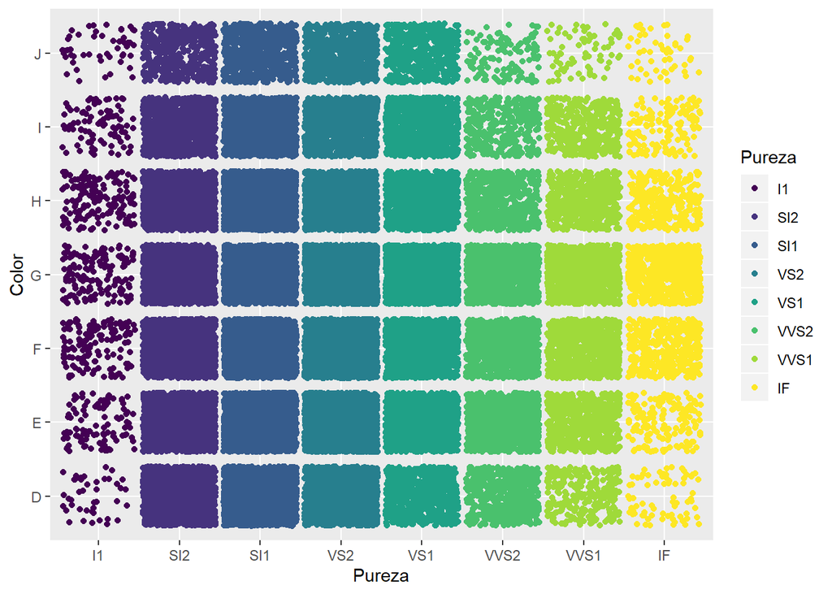

Este gráfico muestra datos curiosos en cuanto a la distribución de los datos conforme al grado de pureza y la coloración de cada uno de los diamantes. Donde los de mayor frecuencia corresponden a los de claridad VS2 y SI1, con coloraciones de F, G y H. Por otra parte, conforme la pureza aumenta hasta IF y el diamante se vuelve incoloro (véase la Figura No. 2), los datos se empiezan a volver menos densos.

## Figura No. 2. Escala de coloración de diamantes

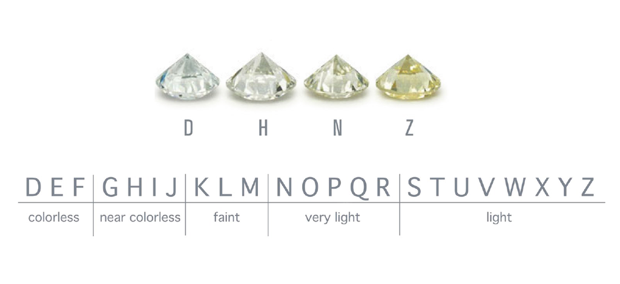

**Fuente: LIBÉLULA, 2020**